# KNN

Pedro Guzmán, Gustavo Cruz

2025-03-20

## Repositorio (revisar branch KNN)

https://github.com/PedroPabloGuzmanMayen/Proyecto2_MD.git

```r
# Chunk para librerias
library(tidyverse)
library(caret)
library(FNN)
library(class)
library(MLmetrics)
```

# Modelo de regresión

Para empezar, se generará un modelo de regresión lineal con el algoritmo KNN para evaluar si es eficiente a la hora de realizar predicciones sobre los precios de venta de las viviendas. Se usara un k_value inicial igual a la raíz cuadrada del número de filas del conjunto de entrenamiento.

## Modelo incial

```r
train <- read.csv("train.csv")

set.seed(245)
porciento <- 0.7
corte <- sample(nrow(train),nrow(train) * porciento)
train <- train[corte, ]
test <- train[-corte, ]

numeric_vars <- c("OverallQual", "GrLivArea", "GarageCars", "TotalBsmtSF",
                 "FullBath", "YearBuilt", "YearRemodAdd", "Fireplaces",
                 "BsmtFinSF1", "LotArea", "MasVnrArea", "WoodDeckSF")

categorical_vars <- c("Neighborhood", "ExterQual", "KitchenQual", "BsmtQual",
                     "GarageFinish", "Foundation", "MSZoning", "CentralAir")

print("Valores NA en el conjunto de prueba (antes de procesar):")
```

```
## [1] "Valores NA en el conjunto de prueba (antes de procesar):"
```

```r
na_test_before <- sapply(test[, c(numeric_vars, categorical_vars)], function(x) sum(is.na(x)))
print(na_test_before)
```

```
##  OverallQual    GrLivArea   GarageCars  TotalBsmtSF     FullBath    YearBuilt
##            0            0            0            0            0            0
## YearRemodAdd   Fireplaces   BsmtFinSF1      LotArea   MasVnrArea   WoodDeckSF
##            0            0            0            0            2            0
## Neighborhood    ExterQual  KitchenQual     BsmtQual GarageFinish   Foundation
##            0            0            0           14           18            0
##     MSZoning   CentralAir
##            0            0
```

```r
for(var in numeric_vars) {
  if(sum(is.na(train[[var]])) > 0) {
    median_value <- median(train[[var]], na.rm = TRUE)
    train[[var]][is.na(train[[var]])] <- median_value
  }

  if(sum(is.na(test[[var]])) > 0) {
    median_value <- median(train[[var]], na.rm = TRUE)  # Usamos la mediana del conjunto de entrenamiento
    test[[var]][is.na(test[[var]])] <- median_value
  }
}

for(var in categorical_vars) {
  if(sum(is.na(train[[var]])) > 0) {
    mode_value <- names(sort(table(train[[var]]), decreasing = TRUE))[1]
    train[[var]][is.na(train[[var]])] <- mode_value
  }

  if(sum(is.na(test[[var]])) > 0) {
    mode_value <- names(sort(table(train[[var]]), decreasing = TRUE))[1]  # Usamos el modo del conjunto de entrenamiento
    test[[var]][is.na(test[[var]])] <- mode_value
  }

  all_levels <- unique(c(levels(factor(train[[var]])), levels(factor(test[[var]]))))
  train[[var]] <- factor(train[[var]], levels = all_levels)
  test[[var]] <- factor(test[[var]], levels = all_levels)
}

print("Valores NA en el conjunto de prueba :")
```

```
## [1] "Valores NA en el conjunto de prueba :"
```

```r
na_test_after <- sapply(test[, c(numeric_vars, categorical_vars)], function(x) sum(is.na(x)))
print(na_test_after)
```

```
##  OverallQual    GrLivArea   GarageCars  TotalBsmtSF     FullBath    YearBuilt
##            0            0            0            0            0            0
## YearRemodAdd   Fireplaces   BsmtFinSF1      LotArea   MasVnrArea   WoodDeckSF
##            0            0            0            0            0            0
## Neighborhood    ExterQual  KitchenQual     BsmtQual GarageFinish   Foundation
##            0            0            0            0            0            0
##     MSZoning   CentralAir
##            0            0
```

```r
predictors_num <- train[, numeric_vars]
predictors_cat <- train[, categorical_vars]

dummies <- dummyVars(~ ., data = predictors_cat, fullRank = TRUE)
predictors_cat_encoded <- predict(dummies, predictors_cat)

X_train <- cbind(predictors_num, predictors_cat_encoded)
y_train <- train$SalePrice

preproc <- preProcess(X_train, method = c("center", "scale"))
X_train_scaled <- predict(preproc, X_train)

predictors_num_test <- test[, numeric_vars]
predictors_cat_test <- test[, categorical_vars]

predictors_cat_test_encoded <- predict(dummies, predictors_cat_test)

X_test <- cbind(predictors_num_test, predictors_cat_test_encoded)

train_cols <- colnames(X_train)
test_cols <- colnames(X_test)

missing_in_test <- setdiff(train_cols, test_cols)
missing_in_train <- setdiff(test_cols, train_cols)

if(length(missing_in_test) > 0) {
  print(paste("Columnas faltantes en test:", paste(missing_in_test, collapse=", ")))
  for(col in missing_in_test) {
    X_test[, col] <- 0
  }
}

if(length(missing_in_train) > 0) {
  print(paste("Columnas en test que no están en train:", paste(missing_in_train, collapse=", ")))
  X_test <- X_test[, !(colnames(X_test) %in% missing_in_train)]
}

X_test <- X_test[, colnames(X_train)]

X_test_scaled <- predict(preproc, X_test)

na_count_test <- sum(is.na(X_test_scaled))
print(paste("Número de NAs en X_test_scaled:", na_count_test))
```

```
## [1] "Número de NAs en X_test_scaled: 0"
```

```r
if(na_count_test > 0) {
  na_cols <- colnames(X_test_scaled)[colSums(is.na(X_test_scaled)) > 0]
  print("Columnas con valores NA:")
  print(na_cols)

  for(col in na_cols) {
    X_test_scaled[is.na(X_test_scaled[, col]), col] <- mean(X_train_scaled[, col], na.rm = TRUE)
  }
}

k_value <- round(sqrt(nrow(train)),0)

knn_model <- train(
  x = X_train_scaled,
  y = y_train,
  method = "knn",
  tuneGrid = data.frame(k = k_value),
  metric = "RMSE"
)

print(knn_model)
```

```
## k-Nearest Neighbors
##
## 1021 samples
##   57 predictor
##
## No pre-processing
## Resampling: Bootstrapped (25 reps)
## Summary of sample sizes: 1021, 1021, 1021, 1021, 1021, 1021, ...
## Resampling results:
##
##   RMSE      Rsquared   MAE
##   49121.32  0.6887407  30528.61
##
## Tuning parameter 'k' was held constant at a value of 32
```

En este modelo inicial se obtuvo un RMSE de 49121.32 y un R2 de 0.68. El RMSE es significativamente mejor que el obtenido en el modelo NaiveBayes pues en dicho modelo el error fue de más de 200,000 dólares. Sin embargo, este modelo es peor que el del árbol de clasificación (37033.09) y el de regresión lineal (38687.16) . Además de eso, el r2 es bastante mejorable. Por esa razón se tuneará el parámetro k y se usará un modelo de validación cruzada para determinar si hay mejores resultados.

## Modelo con tuneo del parámetro k

```r
train <- read.csv("train.csv")

set.seed(245)
porciento <- 0.7
corte <- sample(nrow(train),nrow(train) * porciento)
train <- train[corte, ]
test <- train[-corte, ]

numeric_vars <- c("OverallQual", "GrLivArea", "GarageCars", "TotalBsmtSF",
                 "FullBath", "YearBuilt", "YearRemodAdd", "Fireplaces",
                 "BsmtFinSF1", "LotArea", "MasVnrArea", "WoodDeckSF")

categorical_vars <- c("Neighborhood", "ExterQual", "KitchenQual", "BsmtQual",
                     "GarageFinish", "Foundation", "MSZoning", "CentralAir")

print("Valores NA en el conjunto de prueba (antes de procesar):")
```

```
## [1] "Valores NA en el conjunto de prueba (antes de procesar):"
```

```r
na_test_before <- sapply(test[, c(numeric_vars, categorical_vars)], function(x) sum(is.na(x)))
print(na_test_before)
```

```
##  OverallQual    GrLivArea   GarageCars  TotalBsmtSF     FullBath    YearBuilt
##            0            0            0            0            0            0
## YearRemodAdd   Fireplaces   BsmtFinSF1      LotArea   MasVnrArea   WoodDeckSF
##            0            0            0            0            2            0
## Neighborhood    ExterQual  KitchenQual     BsmtQual GarageFinish   Foundation
##            0            0            0           14           18            0
##     MSZoning   CentralAir
##            0            0
```

```r
for(var in numeric_vars) {
  if(sum(is.na(train[[var]])) > 0) {
    median_value <- median(train[[var]], na.rm = TRUE)
    train[[var]][is.na(train[[var]])] <- median_value
  }

  if(sum(is.na(test[[var]])) > 0) {
    median_value <- median(train[[var]], na.rm = TRUE)  # Usamos la mediana del conjunto de entrenamiento
    test[[var]][is.na(test[[var]])] <- median_value
  }
}

for(var in categorical_vars) {
  if(sum(is.na(train[[var]])) > 0) {
    mode_value <- names(sort(table(train[[var]]), decreasing = TRUE))[1]
    train[[var]][is.na(train[[var]])] <- mode_value
  }

  if(sum(is.na(test[[var]])) > 0) {
    mode_value <- names(sort(table(train[[var]]), decreasing = TRUE))[1]  # Usamos el modo del conjunto de entrenamiento
    test[[var]][is.na(test[[var]])] <- mode_value
  }

  all_levels <- unique(c(levels(factor(train[[var]])), levels(factor(test[[var]]))))
  train[[var]] <- factor(train[[var]], levels = all_levels)
  test[[var]] <- factor(test[[var]], levels = all_levels)
}

print("Valores NA en el conjunto de prueba :")
```

```
## [1] "Valores NA en el conjunto de prueba :"
```

```r
na_test_after <- sapply(test[, c(numeric_vars, categorical_vars)], function(x) sum(is.na(x)))
print(na_test_after)
```

```
##  OverallQual    GrLivArea   GarageCars  TotalBsmtSF     FullBath    YearBuilt
##            0            0            0            0            0            0
## YearRemodAdd   Fireplaces   BsmtFinSF1      LotArea   MasVnrArea   WoodDeckSF
##            0            0            0            0            0            0
## Neighborhood    ExterQual  KitchenQual     BsmtQual GarageFinish   Foundation
##            0            0            0            0            0            0
##     MSZoning   CentralAir
##            0            0
```

```r
predictors_num <- train[, numeric_vars]
predictors_cat <- train[, categorical_vars]

dummies <- dummyVars(~ ., data = predictors_cat, fullRank = TRUE)
predictors_cat_encoded <- predict(dummies, predictors_cat)

X_train <- cbind(predictors_num, predictors_cat_encoded)
y_train <- train$SalePrice

preproc <- preProcess(X_train, method = c("center", "scale"))
X_train_scaled <- predict(preproc, X_train)

predictors_num_test <- test[, numeric_vars]
predictors_cat_test <- test[, categorical_vars]

predictors_cat_test_encoded <- predict(dummies, predictors_cat_test)

X_test <- cbind(predictors_num_test, predictors_cat_test_encoded)

train_cols <- colnames(X_train)
test_cols <- colnames(X_test)

missing_in_test <- setdiff(train_cols, test_cols)
missing_in_train <- setdiff(test_cols, train_cols)

if(length(missing_in_test) > 0) {
  print(paste("Columnas faltantes en test:", paste(missing_in_test, collapse=", ")))
  for(col in missing_in_test) {
    X_test[, col] <- 0
  }
}

if(length(missing_in_train) > 0) {
  print(paste("Columnas en test que no están en train:", paste(missing_in_train, collapse=", ")))
  X_test <- X_test[, !(colnames(X_test) %in% missing_in_train)]
}

X_test <- X_test[, colnames(X_train)]

X_test_scaled <- predict(preproc, X_test)

na_count_test <- sum(is.na(X_test_scaled))
print(paste("Número de NAs en X_test_scaled:", na_count_test))
```

```
## [1] "Número de NAs en X_test_scaled: 0"
```

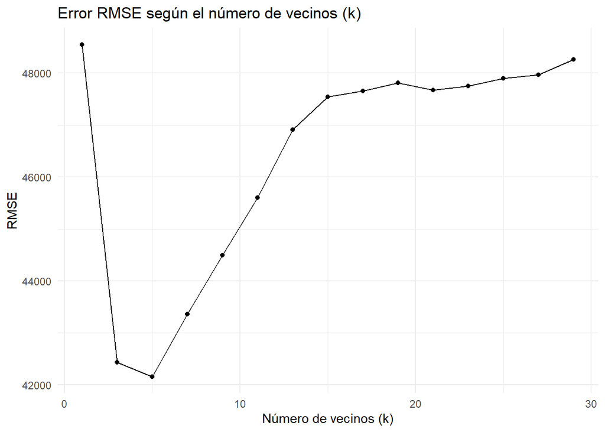

```r
if(na_count_test > 0) {
  na_cols <- colnames(X_test_scaled)[colSums(is.na(X_test_scaled)) > 0]
  print("Columnas con valores NA:")
  print(na_cols)

  for(col in na_cols) {
    X_test_scaled[is.na(X_test_scaled[, col]), col] <- mean(X_train_scaled[, col], na.rm = TRUE)
  }
}

k_values <- seq(1, 30, by = 2)

set.seed(245)
train_control <- trainControl(method = "cv", number = 5)
knn_model <- train(
  x = X_train_scaled,
  y = y_train,
  method = "knn",
  tuneGrid = data.frame(k = k_values),
  trControl = train_control,
  metric = "RMSE"
)

ggplot(knn_model) +
  labs(title = "Error RMSE según el número de vecinos (k)",
       x = "Número de vecinos (k)",
       y = "RMSE") +
  theme_minimal()
```

```r
print(paste("El mejor valor de k es:", knn_model$bestTune$k))
```

```
## [1] "El mejor valor de k es: 5"
```

# Modelo de clasificación

Para el modelo inicial se seleccionara como k el valor de la raíz cuadrada del número de filas del conjunto de entrenamiento

```r
#Crear la variable categoría

mean_price <- mean(train$SalePrice, na.rm = TRUE)
sd_price <- sd(train$SalePrice, na.rm = TRUE)
lower_limit <- median(train$SalePrice)
upper_limit <- mad(train$SalePrice)

train$Category <- ifelse(train$SalePrice < (lower_limit - upper_limit), "Baratas",
                                 ifelse(train$SalePrice > (lower_limit + upper_limit), "Caras", "Medianas"))

test$Category <- ifelse(test$SalePrice < (lower_limit - upper_limit), "Baratas",
                             ifelse(test$SalePrice > (lower_limit + upper_limit), "Caras", "Medianas"))
```

```r
set.seed(245)

to_train <- train %>% mutate_if(is.factor, as.numeric)
to_test <- test %>% mutate_if(is.factor, as.numeric)
y_train <- factor(to_train$Category)
y_test <- factor(to_test$Category)
to_test <- to_test %>% select(-Id) %>% select(-SalePrice)
to_train <- to_train %>% select(-Id) %>% select(-SalePrice)
x_train <- to_train
x_test <- to_test
k <- round(sqrt(nrow(train)),0)
clas_model <- knn(X_train_scaled, X_test_scaled,y_train,k)
clas_model2 <- knn(X_train_scaled, X_train_scaled, y_train, k)
confusionMatrix(clas_model, y_test)
```

```
## Confusion Matrix and Statistics
##
##           Reference
## Prediction Baratas Caras Medianas
##   Baratas        3     0        0
##   Caras          0    39        7
##   Medianas      26    37      216
##
## Overall Statistics
##
##                Accuracy : 0.7866
##                  95% CI : (0.7382, 0.8297)
##     No Information Rate : 0.6799
##     P-Value [Acc > NIR] : 1.2e-05
##
##                   Kappa : 0.4505
##
##  Mcnemar's Test P-Value : NA
##
## Statistics by Class:
##
##                      Class: Baratas Class: Caras Class: Medianas
## Sensitivity                0.103448       0.5132          0.9686
## Specificity                1.000000       0.9722          0.4000
## Pos Pred Value             1.000000       0.8478          0.7742
## Neg Pred Value             0.920000       0.8688          0.8571
## Prevalence                 0.088415       0.2317          0.6799
## Detection Rate             0.009146       0.1189          0.6585
## Detection Prevalence       0.009146       0.1402          0.8506
## Balanced Accuracy          0.551724       0.7427          0.6843
```

```r
confusionMatrix(clas_model2, y_train)
```

```
## Confusion Matrix and Statistics
##
##           Reference
## Prediction Baratas Caras Medianas
##   Baratas       12     0        2
##   Caras          0   109       19
##   Medianas      78   112      689
##
## Overall Statistics
##
##                Accuracy : 0.7933
##                  95% CI : (0.7672, 0.8178)
##     No Information Rate : 0.6954
##     P-Value [Acc > NIR] : 1.176e-12
##
##                   Kappa : 0.4459
##
##  Mcnemar's Test P-Value : NA
##
## Statistics by Class:
##
##                      Class: Baratas Class: Caras Class: Medianas
## Sensitivity                 0.13333       0.4932          0.9704
## Specificity                 0.99785       0.9762          0.3891
## Pos Pred Value              0.85714       0.8516          0.7838
## Neg Pred Value              0.92254       0.8746          0.8521
## Prevalence                  0.08815       0.2165          0.6954
## Detection Rate              0.01175       0.1068          0.6748
## Detection Prevalence        0.01371       0.1254          0.8609
## Balanced Accuracy           0.56559       0.7347          0.6797
```

El modelo de clasificación inicial tiene un acuracy de 0.7866, este accuracy es bastante bueno en comparación a los de los otros modelos de clasificación, pues estos regularmente obtenían valores similares. Por ejemplo, el modelo con NaiveBayes tuvo un accuracy de 0.75 incialmente, el árbol de clasificación obtuvo un 0.88 de accuracy. Un aspecto que hace que este modelo sea deficiente frente a los anteriores es que solamente acertó correctamente con la predicción de las casas baratas el 10% de las veces, los modelos anteriormente mencionados acertaban más del 40% de las ocasiones en esta clasificación.

Otro aspecto relevante es que el modelo no presenta overfitting, pues obtuvo resultados similares tanto con los datos de prueba como con los de entrenamiento, por lo que se intuye que sabe generalizar de buena forma la información.

Basado en los resultados, se concluyé que este modelo es bastante deficente en comparación a los anteriores, se hará un tuneo y una validación cruzada del valor k con este modelo para observar si hay una mejora.

## Tuneo de parámetros para el modelo de clasificación

```r
k_values <- seq(1, 30) #Se intentará con los valores k del 1 al 30
train_control <- trainControl(method = "cv", number = 10)
cv_model <- train(
  x = X_train_scaled,
  y = y_train,
  method = "knn",
  trControl = train_control,
  tuneGrid = data.frame(k = k_values)  # Probar varios valores de k
)

# Ver el mejor valor de k
print(cv_model)
```

```
## k-Nearest Neighbors
##
## 1021 samples
##   57 predictor
##    3 classes: 'Baratas', 'Caras', 'Medianas'
##
## No pre-processing
## Resampling: Cross-Validated (10 fold)
## Summary of sample sizes: 919, 919, 919, 919, 919, 919, ...
## Resampling results across tuning parameters:
##
##   k   Accuracy   Kappa
##    1  0.8050638  0.5654925
##    2  0.8119075  0.5888828
##    3  0.8099657  0.5686721
```

[output cut: 30 more lines]

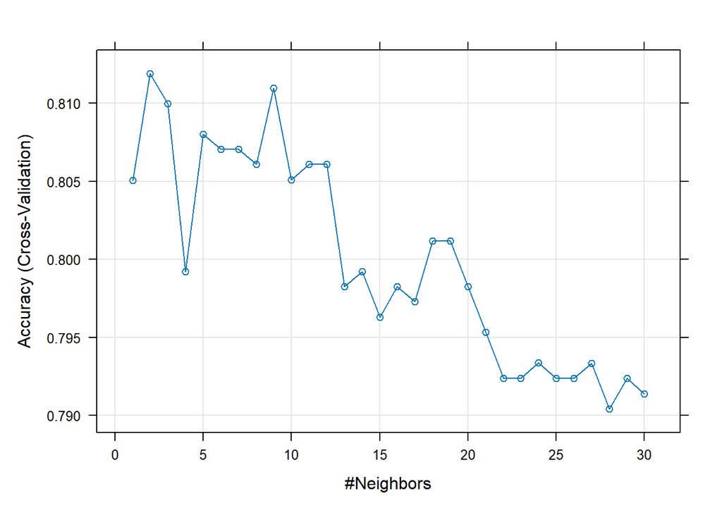

```r
# Graficar el rendimiento para cada valor de k
plot(cv_model)
```

```r
# Hacer predicciones con el modelo ajustado
best_k <- cv_model$bestTune$k  # Mejor valor de k
print(paste("El mejor valor de k es:", best_k))
```

```
## [1] "El mejor valor de k es: 2"
```

```r
# Predicciones finales
final_predictions <- predict(cv_model, newdata = X_test_scaled)

# Evaluar el rendimiento con la matriz de confusión
confusionMatrix(final_predictions, y_test)
```

```
## Confusion Matrix and Statistics
##
##           Reference
## Prediction Baratas Caras Medianas
##   Baratas       22     0       11
##   Caras          0    63        7
##   Medianas       7    13      205
##
## Overall Statistics
##
##                Accuracy : 0.8841
##                  95% CI : (0.8445, 0.9167)
##     No Information Rate : 0.6799
##     P-Value [Acc > NIR] : < 2.2e-16
##
##                   Kappa : 0.7562
##
##  Mcnemar's Test P-Value : NA
##
## Statistics by Class:
##
##                      Class: Baratas Class: Caras Class: Medianas
## Sensitivity                 0.75862       0.8289          0.9193
## Specificity                 0.96321       0.9722          0.8095
## Pos Pred Value              0.66667       0.9000          0.9111
## Neg Pred Value              0.97627       0.9496          0.8252
## Prevalence                  0.08841       0.2317          0.6799
## Detection Rate              0.06707       0.1921          0.6250
## Detection Prevalence        0.10061       0.2134          0.6860
## Balanced Accuracy           0.86092       0.9006          0.8644
```

# Conclusiones

En base a los resultados obtenidos en la generación de modelos de clasificación con distintos algoritmos, se concluyé que el mejor algoritmo para predecir el precio de las viviendas es el algoritmo de random forest, pues este obtuvo resulatados casi perfectos y su tiempo de ejecución, a pesar de ser mayor al resto, no tiene diferencia significativa, por lo tanto se concluye que en este caso, este es el mejor algoritmo que puede utilizarse para clasificar el precio de las viviendas.

En cuánto a la regresión, el modelo con un menor RMSE fue el del árbol de regresión, además de eso este modelo tomaba en cuenta gran parte de las variables para realizar la predicción y tuvo un coeficiente R2 de 0.80, además de eso su tiempo de ejecución es basnate similar al de los demás. Por lo tanto, para la regresión se cincluye que el mejor modelo posible es el árbol de clasificación con 8 niveles, a pesar de eso se sugiere utilizar un modelo de clasificación para hacer predicciones sobre los precios de venta de las viviendas pues en esta clase de modelos se obtienen mejores predicciones.